# StatisticalRethinkingChapter13

# 13M2. Fit this multilevel model to the simulated café data:

Wi ∼ Normal(μi, σ) μi = αcafé[i] + βcafé[i]Ai α café ∼ Normal(α, σα) β café ∼Normal(β,σβ) α ∼ Normal(0, 10) β ∼ Normal(0, 10) σ ∼ HalfCauchy(0, 1) σα ∼ HalfCauchy(0, 1) σβ ∼HalfCauchy(0,1)

Use WAIC to compare this model to the model from the chapter, the one that uses a multi-variate Gaussian prior. Explain the result.

```r
mQ13M1 <- map2stan(
  alist(
    wait ~ dnorm( mu , sigma ),
    mu <- a_cafe[cafe] + b_cafe[cafe]*afternoon,
    c(a_cafe, b_cafe)[cafe] ~ dmvnorm2(Mu = c(a, b), sigma = sigma_cafe, Rho = Rho),
    a ~ dnorm(0, 10),
    b ~ dnorm(0, 10),
    sigma_cafe ~ dcauchy(0, 2),
    sigma ~ dcauchy(0, 2),
    Rho ~ dlkjcorr(2)
  ),
  data=d, iter=5000 , warmup=2000 , chains=2 )
```

```
## recompiling to avoid crashing R session
```

[output not shown]

[output cut: 235 more lines]

[output not shown]

[output not shown]

```
## Computing WAIC
```

```
## Constructing posterior predictions
```

[output not shown]

```r
mQ13M2 <- map2stan(
  alist(
    wait ~ dnorm( mu , sigma ),
    mu <- a_cafe[cafe] + b_cafe[cafe]*afternoon,
    a_cafe[cafe] ~ dnorm(a, sigma_a),
    b_cafe[cafe] ~ dnorm(b, sigma_b),
    a ~ dnorm(0, 10),
    b ~ dnorm(0, 10),
    sigma ~ dcauchy(0, 1),
    sigma_a ~ dcauchy(0, 1),
    sigma_b ~ dcauchy(0, 1)
  ),
  data=d ,
  iter=5000 , warmup=2000 , chains=2 )
```

[output not shown]

[output cut: 235 more lines]

[output not shown]

[output not shown]

```
## Computing WAIC
## Constructing posterior predictions
```

[output not shown]

```r
# compare models
compare(mQ13M1, mQ13M2)
```

```
##         WAIC pWAIC dWAIC weight    SE dSE
## mQ13M1 308.9  26.8   0.0   0.54 20.03  NA
## mQ13M2 309.2  27.0   0.3   0.46 20.15 0.8
```

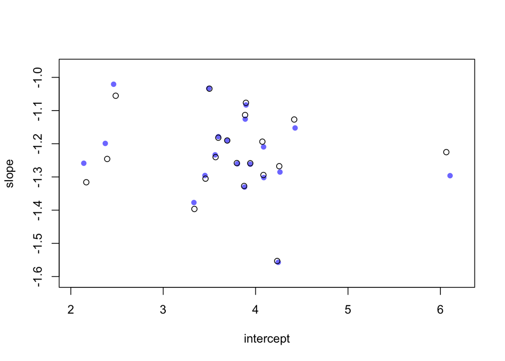

```r
posterior.samples.mQ13M1 <- extract.samples(mQ13M1)
aQ13M1 <- apply( X = posterior.samples.mQ13M1$a_cafe , MARGIN = 2 , FUN = mean )
bQ13M1 <- apply( X = posterior.samples.mQ13M1$b_cafe , MARGIN = 2 , FUN = mean )
posterior.samples.mQ13M2 <- extract.samples(mQ13M2)
aQ13M2 <- apply( X = posterior.samples.mQ13M2$a_cafe, MARGIN = 2 , FUN = mean )
bQ13M2 <- apply( X = posterior.samples.mQ13M2$b_cafe, MARGIN = 2 , FUN = mean )

plot( aQ13M1 , bQ13M1 , xlab="intercept" , ylab="slope" ,
      pch=16 , col=rangi2 , ylim=c( min(bQ13M1)-0.05 , max(bQ13M1)+0.05 ) ,
      xlim=c( min(aQ13M1)-0.1 , max(aQ13M1)+0.1 ) )
points( aQ13M2 , bQ13M2 , pch=1 )
```

# 13M3. Re-estimate the varying slopes model for the UCBadmit data, now using a non-centered pa- rameterization. Compare the efficiency of the forms of the model, using n_eff. Which is better? Which chain sampled faster?

```r
data(UCBadmit)
d <- UCBadmit

d$male <- ifelse( d$applicant.gender=="male" , 1 , 0 )
d$dept_id <- coerce_index( d$dept )

m13M3 <- map2stan(
  alist(
    admit ~ dbinom( applications, p ),
    logit(p) <- a_dept[dept_id] +
      bm_dept[dept_id]*male,
    c(a_dept, bm_dept)[dept_id] ~ dmvnorm2( c(a, bm), sigma_dept, Rho ),
    a ~ dnorm(0, 10),
    bm ~ dnorm(0, 1),
    sigma_dept ~ dcauchy(0, 2),
    Rho ~ dlkjcorr(2)
  ),
  data=d , iter=5000 , warmup=2000 , chains=2 )
```

[output not shown]

[output cut: 235 more lines]

[output not shown]

[output not shown]

```
## Computing WAIC
```

```
## Constructing posterior predictions
```

[output not shown]

```
## Aggregated binomial counts detected. Splitting to 0/1 outcome for WAIC calculation.
```

```r
m13M3_noncentered <- map2stan(
  alist(
    admit ~ dbinom( applications, p ),
    logit(p) <- a_dept[dept_id] + bm_dept[dept_id]*male,
    c(a_dept, bm_dept)[dept_id] ~ dmvnormNC( sigma_dept, Rho ),
    a ~ dnorm(0, 10),
    bm ~ dnorm(0, 1),
    sigma_dept ~ dcauchy(0, 2),
    Rho ~ dlkjcorr(2)
  ),
  data=d , iter=5000 , warmup=2000 , chains=2 )
```

[output not shown]

[output cut: 235 more lines]

[output not shown]

[output not shown]

```
## Computing WAIC
## Constructing posterior predictions
```

[output not shown]

```
## Aggregated binomial counts detected. Splitting to 0/1 outcome for WAIC calculation.
```

```r
# compare centered and non-centered models
compare(m13M3, m13M3_noncentered)
```

```
##                     WAIC pWAIC dWAIC weight    SE  dSE
## m13M3_noncentered 5191.6  11.0   0.0   0.55 57.13   NA
## m13M3             5192.0  11.4   0.4   0.45 57.27 1.03
```

```r
##changed the chain length because it took too long
```

# 13M4. Use WAIC to compare the Gaussian process model of Oceanic tools to the models fit to the same data in Chapter 10. Pay special attention to the effective numbers of parameters, as estimated by WAIC.

```r
library(rethinking)
data(Kline)
d <- Kline

d$log_pop <- log(d$population)
d$contact_high <- ifelse( d$contact=="high" , 1 , 0 )

m10.10 <- map2stan(
    alist(
        total_tools ~ dpois( lambda ),
        log(lambda) <- a + bp*log_pop +
            bc*contact_high + bpc*contact_high*log_pop,
        a ~ dnorm(0,100),
        c(bp,bc,bpc) ~ dnorm(0,1)
), data=d, warmup=2000 , iter=1e4 , chains=4 )
```

[output not shown]

[output cut: 299 more lines]

[output not shown]

```
## Computing WAIC
```

```
## Constructing posterior predictions
```

[output not shown]

```r
precis(m10.10)
```

```
##      Mean StdDev lower 0.89 upper 0.89 n_eff Rhat
## a    0.94   0.37       0.37       1.55 11035    1
## bp   0.26   0.04       0.21       0.32 11037    1
## bc  -0.10   0.84      -1.41       1.28 10839    1
## bpc  0.04   0.09      -0.10       0.19 10842    1
```

```r
library(rethinking)
data(islandsDistMatrix)
# display short column names, so fits on screen
Dmat <- islandsDistMatrix

colnames(Dmat) <- c("Ml","Ti","SC","Ya","Fi","Tr","Ch","Mn","To","Ha")
round(Dmat,1)
```

```
##             Ml  Ti  SC  Ya  Fi  Tr  Ch  Mn  To  Ha
## Malekula   0.0 0.5 0.6 4.4 1.2 2.0 3.2 2.8 1.9 5.7
## Tikopia    0.5 0.0 0.3 4.2 1.2 2.0 2.9 2.7 2.0 5.3
## Santa Cruz 0.6 0.3 0.0 3.9 1.6 1.7 2.6 2.4 2.3 5.4
## Yap        4.4 4.2 3.9 0.0 5.4 2.5 1.6 1.6 6.1 7.2
## Lau Fiji   1.2 1.2 1.6 5.4 0.0 3.2 4.0 3.9 0.8 4.9
## Trobriand  2.0 2.0 1.7 2.5 3.2 0.0 1.8 0.8 3.9 6.7
## Chuuk      3.2 2.9 2.6 1.6 4.0 1.8 0.0 1.2 4.8 5.8
## Manus      2.8 2.7 2.4 1.6 3.9 0.8 1.2 0.0 4.6 6.7
## Tonga      1.9 2.0 2.3 6.1 0.8 3.9 4.8 4.6 0.0 5.0
## Hawaii     5.7 5.3 5.4 7.2 4.9 6.7 5.8 6.7 5.0 0.0
```

```r
data(Kline2) # load the ordinary data, now with coordinates
d <- Kline2
d$society <- 1:10 # index observations

m13.7 <- map2stan(
    alist(
        total_tools ~ dpois(lambda),
        log(lambda) <- a + g[society] + bp*logpop,
        g[society] ~ GPL2( Dmat , etasq , rhosq , 0.01 ),
        a ~ dnorm(0,10),
        bp ~ dnorm(0,1),
        etasq ~ dcauchy(0,1),
        rhosq ~ dcauchy(0,1)
    ),
    data=list(
        total_tools=d$total_tools,
        logpop=d$logpop,
        society=d$society,
        Dmat=islandsDistMatrix),
    warmup=2000 , iter=1e4 , chains=4 )
```

[output not shown]

[output cut: 299 more lines]

[output not shown]

```
## Computing WAIC
```

```
## Constructing posterior predictions
```

[output not shown]

```r
precis(m13.7)
```

```
## 10 vector or matrix parameters omitted in display. Use depth=2 to show them.
```

```
##       Mean StdDev lower 0.89 upper 0.89 n_eff Rhat
## a     1.29   1.18      -0.64       3.04  4742    1
## bp    0.25   0.12       0.07       0.43  6772    1
## etasq 0.37   0.78       0.00       0.74  4714    1
## rhosq 2.18  35.05       0.00       2.13  7473    1
```

```r
compare(m10.10, m13.7)
```

```
##        WAIC pWAIC dWAIC weight    SE   dSE
## m13.7  67.3   4.0   0.0      1  2.18    NA
## m10.10 80.1   4.9  12.8      0 11.20 11.49
```